# OptionButton

# OptionButton lets the player select from a dropdown menu.

`OptionButton` gives the user a compact list of options when clicked. You can customize it in the editor, but its true strength comes from customizing it through code.

In this guide, you will learn:

- What an `OptionButton` can do.
- How to add items to an `OptionButton`.
- Many ways to react to the player’s choice.
- How to attach any data to a menu item.

Contents:

- Setting up an OptionButton
  - Adding options
- OptionButton’s key features
  - Link to base button features
  - Selected and Text
  - The item_focused and item_selected signals
- How to use an OptionButton in practice
  - Difficulty selector
  - Custom game menu with many options
  - Level up and perk selection menu
  - Weapon selector
- Your questions
  - How can I open an OptionButton with an input event?
  - How can I add sections to my dropdown menu?
  - How does this differ from a MenuButton?
  - Can I animate an OptionButton?
  - Can I remove items from the list in code?

## Setting up an OptionButton

### Adding options

The core of an `OptionButton` is that it shows a list of options to the user when they click the button. They can choose which option they want from the list.

There are two ways to add options to your node: using the *Items* button in the toolbar, or adding items in code.

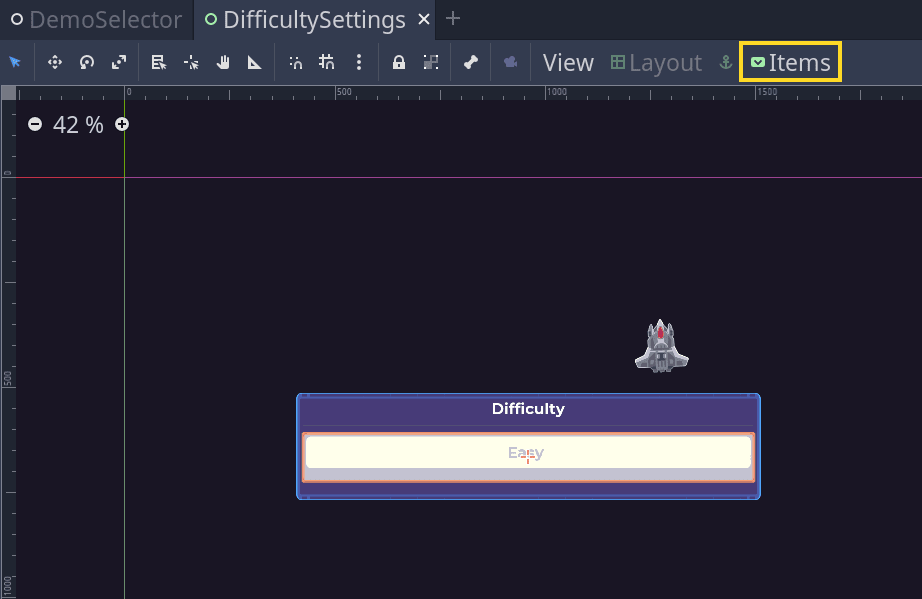

The *Items* dropdown lives above the editor viewport when selecting an `OptionButton`.

**Note:** If there is an error in a script attached to the `OptionButton`, it won’t be visible.

When selected, the item list editor window opens. There, you can add and delete items.

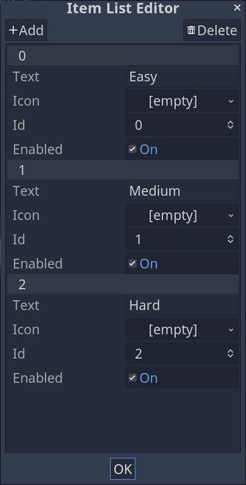

You can customize the *Text*, an *Icon*, and an extra *Id* value for each item. The text and icon will appear to the player when they use the button.

You can treat the list like an `Array`, where each item has a natural index assigned to it. The first item’s index is `0`, and every new item’s index is one higher than the previous.

An item’s index is different than its id. An item can have any positive integer for an id. If you don’t give an item an id, the id is assigned to its index instead.

After you’ve added a list to an `OptionButton`, you can run your scene and click on the `OptionButton` to see your options in a list.

The other way to add a list of options is using the method `add_item()` in code. We will cover this in more detail later on.

## OptionButton’s key features

### Link to base button features

An `OptionButton` is an extension of a class called `BaseButton`. The `BaseButton` class allows many different buttons, such as `CheckButton` and `MenuButton`, to share the same core code. These buttons can all do similar things like:

- Disable themselves to prevent user input.
- Activate when the mouse button is pressed or released.
- Toggle themselves.
- Handle player focus.
- Activate with a keyboard shortcut.
- Function like a radio button using a button group.

You can read the Button guide to learn more about these shared features.

### Selected and Text

An `OptionButton` has two properties dedicated to selecting options and showing which option is selected.

The *Selected* property reports the index of the currently selected option.

The *Text* property shows the text of the currently selected option. This lets the player see their current setting when the `OptionButton` is closed.

**Note:** Selecting an item from the list will overwrite the text. You should avoid setting the *Text* property of the `OptionButton`.

### The item_focused and item_selected signals

`OptionButton` has two signals to respond to user input. The most useful is `item_selected`.

When a user selects an option, the `item_selected` signal emits. It carries the chosen option’s index as a parameter. This signal is the primary way to respond to the user’s choices with an `OptionButton`.

The second signal `item_focused` is more niche. This signal will tell you which option is hovered over when the player navigates UI with a keyboard or game controller.

You can use this to make the change as soon as the player has selected a new option with the keyboard or a game controller.

## How to use an OptionButton in practice

Now we’ll take a look at some practical uses of an `OptionButton`.

### Difficulty selector

When making menus in games, there are many cases where an `OptionButton` is desirable. For example, they are good for difficulty selectors, resolution options, and graphics quality options.

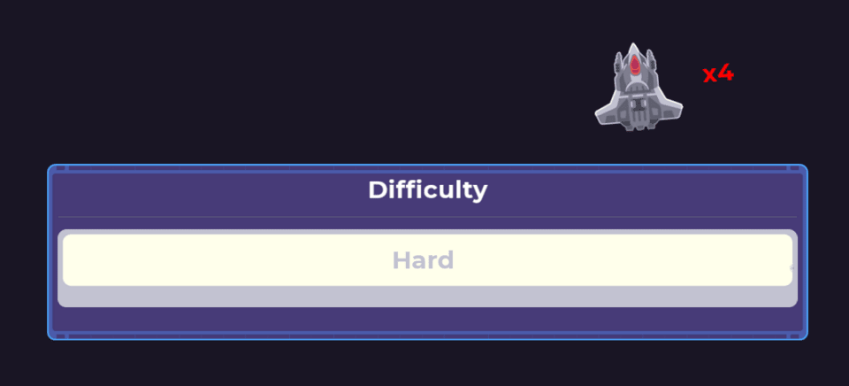

An `OptionButton` makes setting up simple options like this a breeze: using it, we can add difficulty options, including easy, medium, and hard, to the main menu.

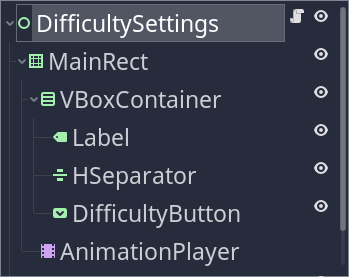

With the `OptionButton` in your menu scene, we can connect its `item_selected` signal to a function.

```
    _difficulty_button.connect("item_selected", self, "update_difficulty")
```

This signal comes with a parameter that tells us the `OptionButton` index that the player just selected. Then the `OptionButton` has a host of methods to get information about the selected option from that index.

In our case, we use `get_item_text()` to check the difficulty text that the user just selected.

```
func update_difficulty(index: int) -> void:
    var difficulty_text: String = _difficulty_button.get_item_text(index)
    match difficulty_text:
        "Easy":
            _enemy_stats_label.text = "x1"
            _enemy_stats_label.modulate = Color.white
        "Medium":
            _enemy_stats_label.text = "x2"
            _enemy_stats_label.modulate = Color.tomato
        "Hard":
            _enemy_stats_label.text = "x4"
            _enemy_stats_label.modulate = Color.red
        _:
            push_error("Unexpected difficulty mode")
```

Match statements are a great way to handle the results of choosing from an option button, as you can tell your program how to treat each entry independently, without taking up as much space as a long series of if and else statements.

The `_` case handles any result from the `OptionButton` that didn’t match any other options. This can help us quickly find if we’ve misspelled an option or forgotten to add a case.

In our script, we take the chosen difficulty and update some visuals to show the enemies will be more challenging in this mode. You may want to use a singleton or similar approach to save the difficulty of your game to use elsewhere in code.

### Custom game menu with many options

Some games in the strategy genre, like the *Civilization* series, have many player choices. Their setup menus can have dozens of modal options, from map size to selecting player teams and win conditions.

[figure not shown]

*Game: Sid Meier’s Civilization V (2010)*

In Godot, you can generate items for an `OptionButton` through code using the `add_item()` function. You can use *Dictionaries* and *Arrays* along with `for` loops to iterate through your data to create items.

```
    # We map buttons to game customization options.
    var map := {
        mode_button: ["free for all", "team deathmatch", "king of the hill"],
        map_button: ["asteroid belt", "titan", "dune"],
        map_size_button: ["small", "medium", "large"],
    }
    # This allows us to populate the option lists in code.
    for button in map:
        for item in map[button]:
            button.add_item(item)
```

When handling many options like this, using the `item_selected` signal is less useful: You likely don’t need to respond immediately to every single `OptionButton` change.

Instead, you can wait until the player made all their choices, then check the *Selected* property of each `OptionButton` when the user opts to save or leave the page.

This is why it can be helpful to create an `Array` of the involved `OptionButton` instances and loop through each of them to get their *Selected* property.

We define functions that update a `Label` to show the choices in a loading screen.

We call these functions from an `AnimationPlayer` sequentially.

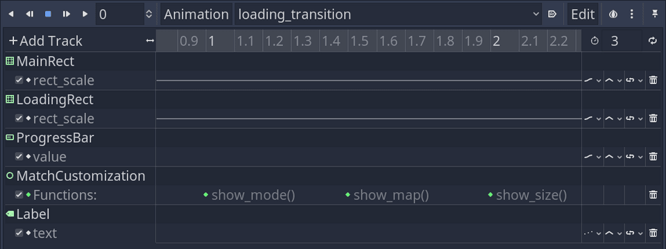

To access the id of the currently selected item, you can use the `get_selected_id()` function on the `OptionButton`. Then pass that id into one of the other getter functions like `get_item_text()`.

```
func show_mode() -> void:
    _label.text = _option_list.mode_button.get_item_text(_option_list.mode_button.get_selected_id())


func show_map() -> void:
    _label.text = _option_list.map_button.get_item_text(_option_list.map_button.get_selected_id())


func show_size() -> void:
    _label.text = _option_list.map_size_button.get_item_text(_option_list.map_size_button.get_selected_id())
```

In this case, we didn’t give a unique value to *Id*, so an item’s id functions the same as its index.

### Level up and perk selection menu

Many games have level-up options that involve choosing one entry from a small selection, which you can treat as radio buttons or a dropdown menu.

If you have icons representing perks, an `OptionButton` can become an easy and clean way to let your user make choices.

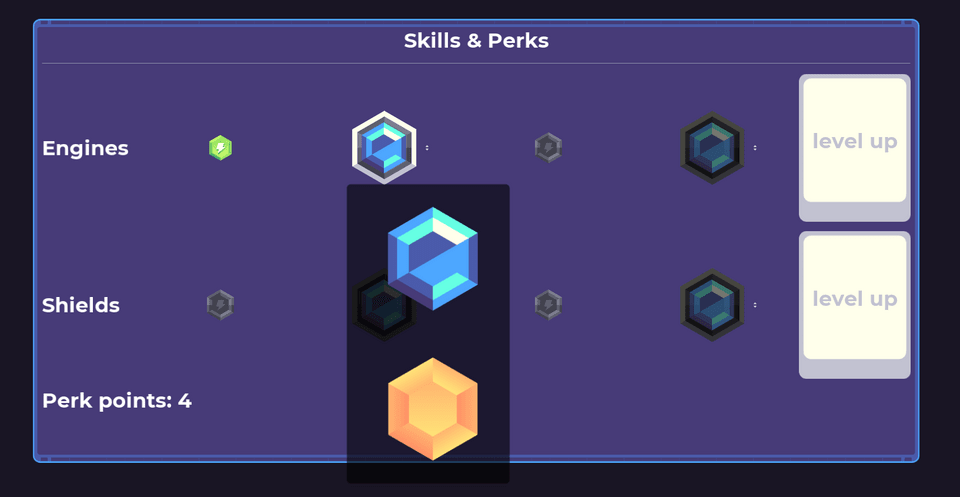

With careful use of themes, you can make option buttons that are entirely texture-based. This can be great for letting players select perks that fill slots from a list.

We have a system by which the player can unlock minor passive or major abilities in a dropdown.

Until they purchase the appropriate level with level-up points, we disable the buttons.

We have a few textures to make this work, a background texture for the `OptionButton`, applied to its `StyleBox`, and gems that fit a slot in the texture. We add these gems as options to the button.

A visual consideration is to make sure the background `StyleBox` and the gem textures fit together. It’s impossible to resize textures inside a `StyleBox` reliably, so ensuring each option’s texture is the same size will make the options look consistent.

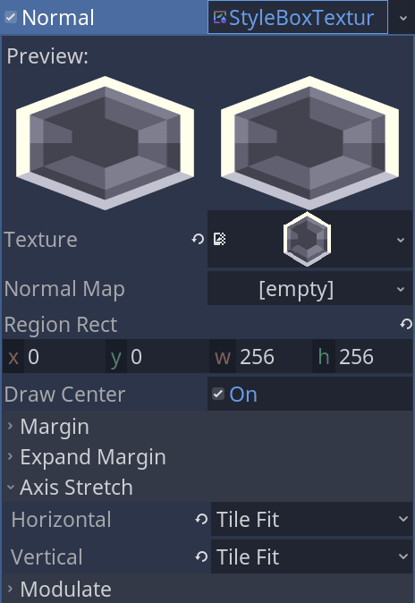

The final stage to getting the right look is customizing the appearance of the `PopupMenu`.

Behind the scenes, an `OptionButton` creates a `PopupMenu` containing all of your options, then when you click on the button, this popup becomes visible.

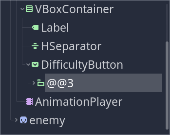

Themes are the best practice for styling UI elements. You can learn more about setting up a theme in the [official GUI skinning guide](https://docs.godotengine.org/en/stable/tutorials/ui/gui_skinning.html).

Just add a theme to your `OptionButton` and add a `PopupMenu` class item to your theme, then you can customize its appearance to your heart’s content.

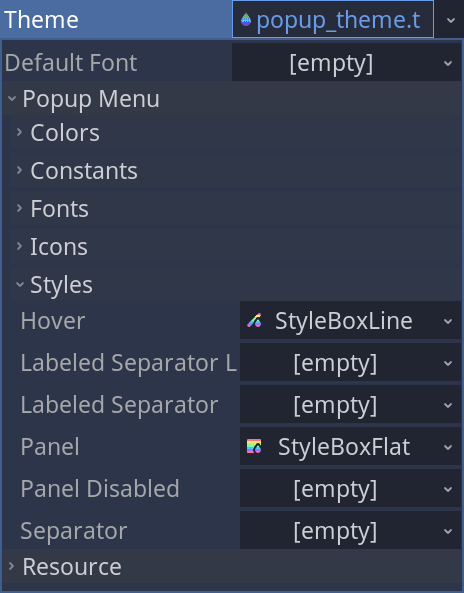

### Weapon selector

You may want an `OptionButton` to control game states, such as selecting an AI’s weapon or behavior.

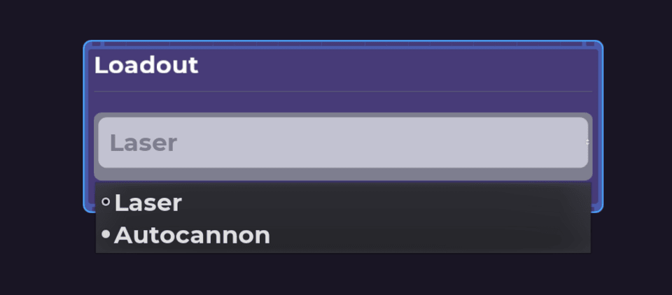

In cases like this, it’s handy to store extra information in the `OptionButton` item itself. We can create an equipment menu for the player to choose a primary weapon, and each option can contain a reference to the weapon itself.

You can save any variable as metadata for an option using the `set_item_metadata()` function. This function takes the index of the option to save to as well as the variable to store.

Once saved, you can retrieve the metadata for the currently selected item using the `get_selected_metadata()` function.

We have two packed scenes containing weapons the player can use. Then we can save references to those packed scenes in their respective option in the `OptionButton`.

```
export var laser: PackedScene
export var autocannon: PackedScene

func _ready() -> void:
    _weapon_list = {"Laser": laser, "Autocannon": autocannon}
    for weapon in _weapon_list:
        _weapon_button.add_item(weapon)
        # Whenever an item is added, by default it goes to the end of the OptionButton. as a result
        # We can get its index by looking up the number of options with get_item_count().
        _weapon_button.set_item_metadata(_weapon_button.get_item_count() - 1, _weapon_list[weapon])
    _weapon_button.connect("item_selected", self, "weapon_selected")
    # We run the weapon selected function here, to automatically equip the default option when the
    # Game starts.
    weapon_selected(_weapon_button.get_selected_id())
```

We need to create our `weapon_selected()` function that retrieves the weapon from the `OptionButton` metadata.

```
func weapon_selected(_weapon_id: int) -> void:
    var new_weapon = _weapon_button.get_selected_metadata().instance()
    _player.change_weapon(new_weapon)
```

The player node has a method to remove its current weapon and attach a new weapon passed in its place.

To create the weapon, we get it from metadata and instance it from the `PackedScene`.

**Note:** We can also get the metadata from its option index using the `get_item_metadata()` function.

## Your questions

### How can I open an OptionButton with an input event?

As an `OptionButton` extends from the `BaseButton` node, you get access to many useful built-in features, including the often-overlooked `ShortCut` resource!

Add a shortcut to your `OptionButton` and choose the `InputEvent`, then whenever you press that input, the `PopupMenu` for your button opens.

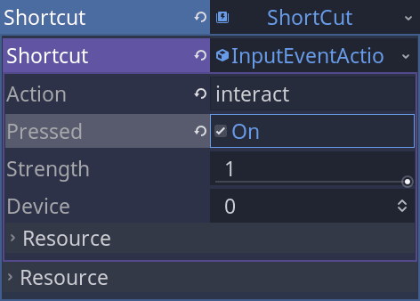

### How can I add sections to my dropdown menu?

In code, you have much finer control over your `PopupMenu` appearance and gain access to some helper functions that alter its appearance.

One of those functions is `add_separator()`. it adds an `HSeparator` below all the current options, so when setting up your `OptionButton`, you need to be wary of the order in which you add objects.

You can also use the `get_popup()` function to access the `PopupMenu` node itself and `add_children` directly to the node.

### How does this differ from a MenuButton?

A `MenuButton` is specifically for interface design and doesn’t show the selected option when unused but instead has placeholder text.

It functions in the same way as the file, edit or view menu button in an office application, where more options can be better grouped.

Retrieving the options from a `MenuButton` is more complicated because the options are part of a `PopupMenu` that has to be accessed first, using `get_popup()` without seeing the menu’s contents in-editor.

An `OptionButton`’s items are much easier to access using the *Items* menu in the editor, as well as with functions like `get_item_index()` that can be called on the button itself.

### Can I animate an OptionButton?

`OptionButton` nodes have a lot of behavior built into its base class, limiting your ability to animate it. It’s one of Godot’s UI nodes designed more for editor plugins and application development than games.

If you produce sprite sheets for your UI elements with animation software, you can use animated textures as the textures on the `OptionButton` style boxes.

However, it is worth considering implementing a personalized version of an `OptionButton` for total control, using `Button` nodes with *Toggle* enabled, and either a `PopupMenu` or a `PanelContainer` if you want to fade in a menu as it is selected.

You can learn more about Button and PanelContainer in their respective guides.

### Can I remove items from the list in code?

Yes, there are two functions to let you dynamically remove items in code. The `clear()` function removes all items from the `OptionButton`, and the `remove_item()` function removes an item at a given index.